# Udacity Project 1: The Science of Decisions

Throughout this report, I will refer to congruent task when talking about the task when the words are congruent their color and to incongruent task when talking about the task when the words are incongruent with their color.

## 1. Independent and Dependent Variables

- Independent Variable: Congruency of Words and Their Color
- Dependent Variable: Time to Complete the Task

## 2. Hypothesis and Appropriate Statistical Test

### Hypotheses

- **Null Hypothesis** (H0): The population mean of time to complete congruent task is equal to the population mean of time to complete incongruent task $$H_0:\mu_c=\mu_i$$ $$H_0:\mu_c-\mu_i=0$$ $$H_0:\mu_D=0$$
- **Alternative Hypothesis** (H1): The population mean of time to complete congruent task is different from the population mean of time to complete incongruent task $$H_1:\mu_c\neq\mu_i$$ $$H_1:\mu_c-\mu_i\neq0$$ $$H_1:\mu_D\neq0$$

### Appropriate Statistical Test

An appropriate test for this analysis is **t-test** for dependent samples because of the followings:

1. Population mean and population standard deviation is unknown.
2. The samples are dependent because the experiment is conducted with *within-subject design* where each participant is measured repeatedly under different conditions.
3. The data are paired.

## 3. Descriptive Statistics

Below is some of statistics of the data:

```python
import pandas as pd

# Path to CSV file of the data
path = r'stroopdata.csv'

# Read the data in CSV file
dataFrame = pd.read_csv(path)

# Showing the data
dataFrame
```

|  | Congruent | Incongruent |
| --- | --- | --- |
| 0 | 12.079 | 19.278 |
| 1 | 16.791 | 18.741 |
| 2 | 9.564 | 21.214 |
| 3 | 8.630 | 15.687 |
| 4 | 14.669 | 22.803 |
| 5 | 12.238 | 20.878 |
| 6 | 14.692 | 24.572 |
| 7 | 8.987 | 17.394 |
| 8 | 9.401 | 20.762 |
| 9 | 14.480 | 26.282 |
| 10 | 22.328 | 24.524 |
| 11 | 15.298 | 18.644 |
| 12 | 15.073 | 17.510 |
| 13 | 16.929 | 20.330 |
| 14 | 18.200 | 35.255 |
| 15 | 12.130 | 22.158 |
| 16 | 18.495 | 25.139 |
| 17 | 10.639 | 20.429 |
| 18 | 11.344 | 17.425 |
| 19 | 12.369 | 34.288 |
| 20 | 12.944 | 23.894 |
| 21 | 14.233 | 17.960 |
| 22 | 19.710 | 22.058 |
| 23 | 16.004 | 21.157 |

```python
# Difference of paired data to be analyzed
difference = dataFrame['Congruent'] - dataFrame['Incongruent']
print "The difference tab: \n", difference, "\n"

# Storing mean of the difference in a var
mean = difference.mean()
print "The mean of Difference is", mean

# Storing median of the difference in a var
median = difference.median()
print "The median of Difference is", median

# Storing sample standard deviation of the difference in a var
std = difference.std()
print "The standard deviation of Difference is", std
```

```
The difference tab:
0     -7.199
1     -1.950
2    -11.650
3     -7.057
4     -8.134
5     -8.640
6     -9.880
7     -8.407
8    -11.361
9    -11.802
10    -2.196
11    -3.346
12    -2.437
13    -3.401
14   -17.055
15   -10.028
16    -6.644
17    -9.790
18    -6.081
19   -21.919
20   -10.950
21    -3.727
22    -2.348
23    -5.153
dtype: float64

The mean of Difference is -7.96479166667
The median of Difference is -7.6665
The standard deviation of Difference is 4.86482691036
```

## 4. Visualizations

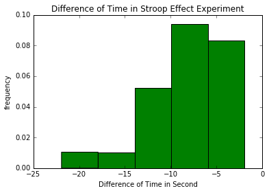

```python
# Causes plots to display within the notebook rather than in a new window
%pylab inline

import matplotlib.pyplot as plt

plt.hist(difference, 5, normed=1, facecolor="green")
plt.xlabel("Difference of Time in Second")
plt.ylabel("frequency")
plt.title("Difference of Time in Stroop Effect Experiment")
plt.show()
```

## 5. Statistical Test

- **Alpha Level** = **.05**
- **Degrees of Freedom** = n - 1 = 24 - 1 = **23**
- **t-critical Value** (two-tails) = **2.069 and -2.069**

Calculating t-value:

```python
t = mean / (std / (24**.5))

print "t value is equal to", t
```

```
t value is equal to -8.02070694411
```

- **Reject H0** because t-value falls within the lower tail of critical region
- **Conclusion**: The time to complete the incongruent task is **significantly different** with the time to complete the congruent task. Moreover, the time to complete the incongruent task is **significantly greater** than the time to complete the congruent task because the t-value falls within the lower tail of the critical region.

## 6. Discussion

### Plausible Explanation

As analyzed above, the data suggests that people would take longer time to tell the color of the word when the written word and its color are incongruent. One possible explanation of this is that it might be the case that people learn a pattern from the first task, the congruent one, that the word and its color would tell the same thing. When that is not the case anymore in the second task, they would do worse because they have to unlearn the rule from the first task and start learning the pattern again from scratch.

### Further Experiment

A further experiment to test this explanation would be to measure the speed of typing of people typing using QUERTY keyboard for the first task and typing using DVORAK keyboard for the second task. This might test the explanation that people tend to built a layer of pattern to do certain task and it is typing in qwerty in this case. When the pattern is taken out from them, using DVORAK keyboard, they would do worse.

## Caveat

Downside of the experiment above might be that there are some people who might already familiar with typing on DVORAK keyboards. In that case, the keyboards for the second task could be replaced with a keyboard with randomized keys is neither QWERTY nor DVORAK.